# Machine Learning - Project

bshad74

March 14, 2016

```
## Run time: 2016-03-15 19:40:27
## R version: R version 3.2.3 (2015-12-10)
```

# 1. Synopsis

It is now possible to collect a large amount of data about personal activity relatively inexpensively Using devices such as Jawbone Up, Nike FuelBand, and Fitbit . Data such as how much of a particular activity they do. While quantity of the activity can be seen, they rarely quantify how well they do it. In this project, goal is to use data from accelerometers on the belt, forearm, arm, and dumbell of 6 participants. They were asked to perform barbell lifts correctly and incorrectly in 5 different ways. More information is available from the website here: http://groupware.les.inf.puc-rio.br/har (see the section on the Weight Lifting Exercise Dataset).

The goal of this project is to predict the manner in which the participants did the exercise. This is the “classe” variable in the training set.

## 1.1 Data

The training and test data for this project was downloaded from the following sources respectively:

https://d396qusza40orc.cloudfront.net/predmachlearn/pml-training.csv

https://d396qusza40orc.cloudfront.net/predmachlearn/pml-testing.csv

# 2. Methodology

According to the principles of cross-validation, the data was preprocessed to find the relevant variables and format the data so that a classifier could be run on it.

The following are the main principles of cross-validation that the my model abides by: 1. Use the training set. 2. Split it into training/test sets. 3. Build a model on the training set. 4. Evaluate on the test set. 5. Repeat and average the estimated errors.

## 2.1 Reproducibility

An overall pseudo-random number generator seed was set at 33833 for all code. In order to reproduce the results below, the same seed should be used. Different packages were downloaded and installed, such as caret and randomForest. These should also be installed in order to reproduce the results below.

## 2.2 The Model

Classe is an outcome variable, which is a factor variable with 5 levels. For this data set, “participants were asked to perform one set of 10 repetitions of the Unilateral Dumbbell Biceps Curl in 5 different fashions:

- exactly according to the specification (Class A)
- throwing the elbows to the front (Class B)
- lifting the dumbbell only halfway (Class C)
- lowering the dumbbell only halfway (Class D)
- throwing the hips to the front (Class E)

## 2.3 Cross-validation

Cross-validation will be done by splitting training data set randomly without replacement into 2 subsamples: DTrain data (60% of the original Training data set) and Crossv data (40%). Our models will be fitted on the DTrain data set, and tested on the Crossv data. Once the most accurate model is choosen, it will be tested on the provided Testing data set.

# 3. Data Processing and Modelling

## 3.1 Load libraries, set working Directory and set Seed

## 3.2 Load data, Remving NAs and subsetting the primary

First we want to load the data sets into R and make sure that missing values are coded correctly. Irrelevant variables will be deleted. Results will be hidden from the report for clarity and space considerations.

## 3.3. Removing NAs/Cleaning data and subsetting the primary dataset

Subset the primary dataset to include only the **predictor candidates** and the outcome variable, `classe`.

**Predictor:** Belt, Arm, Dumbell and forearm with no missing values

```
## [1] 19622    53
```

```
##  [1] "classe"               "roll_belt"            "pitch_belt"
##  [4] "yaw_belt"             "total_accel_belt"     "gyros_belt_x"
##  [7] "gyros_belt_y"         "gyros_belt_z"         "accel_belt_x"
## [10] "accel_belt_y"         "accel_belt_z"         "magnet_belt_x"
## [13] "magnet_belt_y"        "magnet_belt_z"        "roll_arm"
## [16] "pitch_arm"            "yaw_arm"              "total_accel_arm"
## [19] "gyros_arm_x"          "gyros_arm_y"          "gyros_arm_z"
## [22] "accel_arm_x"          "accel_arm_y"          "accel_arm_z"
## [25] "magnet_arm_x"         "magnet_arm_y"         "magnet_arm_z"
## [28] "roll_dumbbell"        "pitch_dumbbell"       "yaw_dumbbell"
## [31] "total_accel_dumbbell" "gyros_dumbbell_x"     "gyros_dumbbell_y"
## [34] "gyros_dumbbell_z"     "accel_dumbbell_x"     "accel_dumbbell_y"
## [37] "accel_dumbbell_z"     "magnet_dumbbell_x"    "magnet_dumbbell_y"
## [40] "magnet_dumbbell_z"    "roll_forearm"         "pitch_forearm"
## [43] "yaw_forearm"          "total_accel_forearm"  "gyros_forearm_x"
## [46] "gyros_forearm_y"      "gyros_forearm_z"      "accel_forearm_x"
## [49] "accel_forearm_y"      "accel_forearm_z"      "magnet_forearm_x"
## [52] "magnet_forearm_y"     "magnet_forearm_z"
```

Here how the Data count looks like after Making `classe` into a factor.

```
##    classe    N
## 1:      A 5580
## 2:      B 3797
## 3:      C 3422
## 4:      D 3216
## 5:      E 3607
```

Split the dataset into a 60% training and 40% Cross Validation dataset. Preprocess the Training dataset and Corss Validation dataset prediction variables by centering and scaling.

```
## Created from 11776 samples and 52 variables
##
## Pre-processing:
##   - centered (52)
##   - ignored (0)
##   - scaled (52)
```

Apply the centering and scaling to the Cross Validation dataset.

Check for near zero variance.

```
## No variables with near zero variance
```

Examine groups of prediction (Belt, Arm, Dumbell and forearm) variables.

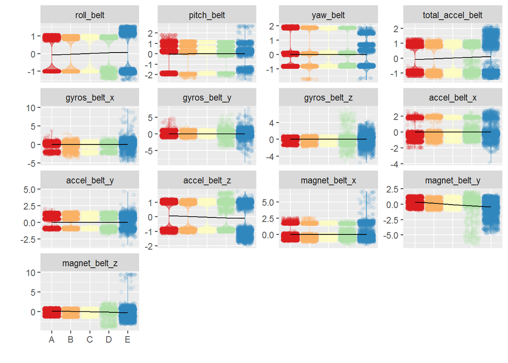

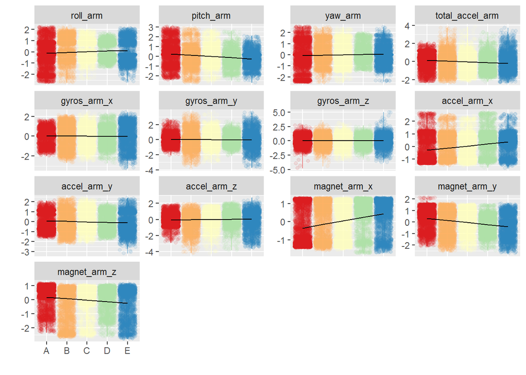

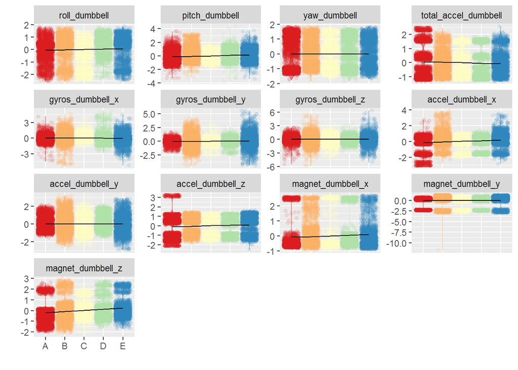

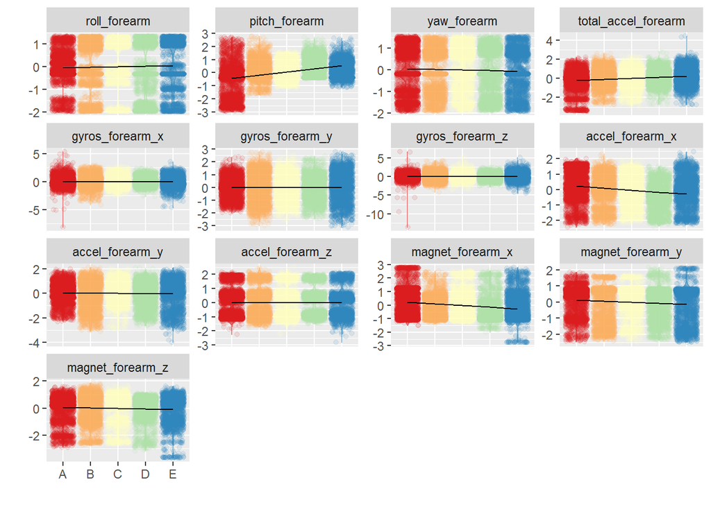

# 4. Train prediction models

Using random forest, the out of sample error should be small. The error will be estimated using the 40% Cross Validation sample. Error estimate of 3% or less would be acceptable.

**Model1 - RandomForest.**

```
##    user  system elapsed
##   39.54    1.14 2393.55
```

Stop the clusters.

## 4.1 Evaluate the Training models

### 4.1.1. Confusion Matrix Model (RandomForest) - Traing Dataset

```
## Random Forest
##
## 11776 samples
##    52 predictor
##     5 classes: 'A', 'B', 'C', 'D', 'E'
##
## No pre-processing
## Resampling: Bootstrapped (25 reps)
## Summary of sample sizes: 11776, 11776, 11776, 11776, 11776, 11776, ...
## Resampling results across tuning parameters:
##
##   mtry  Accuracy   Kappa      Accuracy SD  Kappa SD
##    2    0.9861773  0.9825145  0.002509642  0.003182301
##   27    0.9856286  0.9818223  0.002403773  0.003041877
##   52    0.9770433  0.9709576  0.006147274  0.007792574
##
## Accuracy was used to select the optimal model using  the largest value.
## The final value used for the model was mtry = 2.
```

```
## Confusion Matrix and Statistics
##
##           Reference
## Prediction    A    B    C    D    E
##          A 3348    0    0    0    0
##          B    0 2279    0    0    0
##          C    0    0 2054    0    0
##          D    0    0    0 1930    0
##          E    0    0    0    0 2165
##
## Overall Statistics
##
##                Accuracy : 1
##                  95% CI : (0.9997, 1)
##     No Information Rate : 0.2843
##     P-Value [Acc > NIR] : < 2.2e-16
##
##                   Kappa : 1
##  Mcnemar's Test P-Value : NA
##
## Statistics by Class:
##
##                      Class: A Class: B Class: C Class: D Class: E
## Sensitivity            1.0000   1.0000   1.0000   1.0000   1.0000
## Specificity            1.0000   1.0000   1.0000   1.0000   1.0000
## Pos Pred Value         1.0000   1.0000   1.0000   1.0000   1.0000
## Neg Pred Value         1.0000   1.0000   1.0000   1.0000   1.0000
## Prevalence             0.2843   0.1935   0.1744   0.1639   0.1838
## Detection Rate         0.2843   0.1935   0.1744   0.1639   0.1838
## Detection Prevalence   0.2843   0.1935   0.1744   0.1639   0.1838
## Balanced Accuracy      1.0000   1.0000   1.0000   1.0000   1.0000
```

### 4.1.2. Confusion Matrix Model (RandomForest) - Crossv

```
## Confusion Matrix and Statistics
##
##           Reference
## Prediction    A    B    C    D    E
##          A 2225    7    0    0    0
##          B    6 1508   16    0    0
##          C    1    3 1351   29    0
##          D    0    0    1 1256    5
##          E    0    0    0    1 1437
##
## Overall Statistics
##
##                Accuracy : 0.9912
##                  95% CI : (0.9889, 0.9932)
##     No Information Rate : 0.2845
##     P-Value [Acc > NIR] : < 2.2e-16
##
##                   Kappa : 0.9889
##  Mcnemar's Test P-Value : NA
##
## Statistics by Class:
##
##                      Class: A Class: B Class: C Class: D Class: E
## Sensitivity            0.9969   0.9934   0.9876   0.9767   0.9965
## Specificity            0.9988   0.9965   0.9949   0.9991   0.9998
## Pos Pred Value         0.9969   0.9856   0.9762   0.9952   0.9993
## Neg Pred Value         0.9988   0.9984   0.9974   0.9954   0.9992
## Prevalence             0.2845   0.1935   0.1744   0.1639   0.1838
## Detection Rate         0.2836   0.1922   0.1722   0.1601   0.1832
## Detection Prevalence   0.2845   0.1950   0.1764   0.1608   0.1833
## Balanced Accuracy      0.9978   0.9950   0.9912   0.9879   0.9982
```

# 5. Decision

```
## rf variable importance
##
##   only 20 most important variables shown (out of 52)
##
##                      Overall
## roll_belt             100.00
## yaw_belt               80.45
## magnet_dumbbell_z      72.38
## magnet_dumbbell_y      66.56
## pitch_forearm          62.96
## pitch_belt             61.57
## roll_forearm           54.60
## magnet_dumbbell_x      53.09
## magnet_belt_z          46.76
## roll_dumbbell          45.36
## accel_dumbbell_y       44.24
## accel_belt_z           42.95
## magnet_belt_y          39.44
## roll_arm               38.00
## accel_dumbbell_z       37.53
## accel_forearm_x        34.18
## total_accel_dumbbell   29.62
## yaw_dumbbell           29.61
## accel_dumbbell_x       29.48
## magnet_arm_y           28.86
```

```
##
## Call:
##  randomForest(x = x, y = y, mtry = param$mtry)
##                Type of random forest: classification
##                      Number of trees: 500
## No. of variables tried at each split: 2
##
##         OOB estimate of  error rate: 0.87%
## Confusion matrix:
##      A    B    C    D    E class.error
## A 3343    2    2    1    0 0.001493429
## B   19 2252    8    0    0 0.011847301
## C    0   16 2035    3    0 0.009250243
## D    0    0   44 1884    2 0.023834197
## E    0    0    3    3 2159 0.002771363
```

Save training model object for later.

# 6. Predict on the test data

Load the training model.

```
## Loading objects:
##   trainingModel
```

Get predictions and evaluate.

```
##     hatm V1 user_name raw_timestamp_part_1 raw_timestamp_part_2
##  1:    B  1     pedro           1323095002               868349
##  2:    A  2    jeremy           1322673067               778725
##  3:    B  3    jeremy           1322673075               342967
##  4:    A  4    adelmo           1322832789               560311
##  5:    A  5    eurico           1322489635               814776
##  6:    E  6    jeremy           1322673149               510661
##  7:    D  7    jeremy           1322673128               766645
##  8:    B  8    jeremy           1322673076                54671
##  9:    A  9  carlitos           1323084240               916313
## 10:    A 10   charles           1322837822               384285
## 11:    B 11  carlitos           1323084277                36553
## 12:    C 12    jeremy           1322673101               442731
## 13:    B 13    eurico           1322489661               298656
## 14:    A 14    jeremy           1322673043               178652
```

[output cut: 27 more lines]

## 6.1. Submission for Assessment

Create submission files.

```r
pml_write_files = function(x){
  n = length(x)
    for(i in 1:n){
    filename = paste0("problem_id_",i,".txt")
    write.table(x[i],file=filename,quote=FALSE,row.names=FALSE,col.names=FALSE)
  }
}
pml_write_files(hatm)
```

*References*

- [1] Velloso, E.; Bulling, A.; Gellersen, H.; Ugulino, W.; Fuks, H. Qualitative Activity Recognition of Weight Lifting Exercises. Proceedings of 4th International Conference in Cooperation with SIGCHI (Augmented Human ’13) . Stuttgart, Germany: ACM SIGCHI, 2013.